# Risk Factor Analysis

## Outcome Variable

**Outcome Variable:** sstunted

## Predictor Variables

**Intervention Variable:** nchldlt5

**Adjustment Set:**

unadjusted

## Stratifying Variables

The analysis was stratified on these variable(s):

- agecat
- studyid
- country

## Data Summary

| agecat | studyid | country | nchldlt5 | sstunted | n_cell | n |
| --- | --- | --- | --- | --- | --- | --- |
| Birth | ki1000108-IRC | INDIA | 1 | 0 | 79 | 274 |
| Birth | ki1000108-IRC | INDIA | 1 | 1 | 5 | 274 |
| Birth | ki1000108-IRC | INDIA | 2+ | 0 | 185 | 274 |
| Birth | ki1000108-IRC | INDIA | 2+ | 1 | 5 | 274 |
| Birth | ki1017093c-NIH-Crypto | BANGLADESH | 1 | 0 | 17 | 19 |
| Birth | ki1017093c-NIH-Crypto | BANGLADESH | 1 | 1 | 1 | 19 |
| Birth | ki1017093c-NIH-Crypto | BANGLADESH | 2+ | 0 | 1 | 19 |
| Birth | ki1017093c-NIH-Crypto | BANGLADESH | 2+ | 1 | 0 | 19 |
| Birth | kiGH5241-JiVitA-3 | BANGLADESH | 1 | 0 | 21292 | 25142 |
| Birth | kiGH5241-JiVitA-3 | BANGLADESH | 1 | 1 | 2916 | 25142 |
| Birth | kiGH5241-JiVitA-3 | BANGLADESH | 2+ | 0 | 850 | 25142 |
| Birth | kiGH5241-JiVitA-3 | BANGLADESH | 2+ | 1 | 84 | 25142 |
| 6 months | ki1000108-IRC | INDIA | 1 | 0 | 78 | 288 |
| 6 months | ki1000108-IRC | INDIA | 1 | 1 | 11 | 288 |
| 6 months | ki1000108-IRC | INDIA | 2+ | 0 | 188 | 288 |
| 6 months | ki1000108-IRC | INDIA | 2+ | 1 | 11 | 288 |
| 6 months | ki1017093b-PROVIDE | BANGLADESH | 1 | 0 | 416 | 435 |
| 6 months | ki1017093b-PROVIDE | BANGLADESH | 1 | 1 | 10 | 435 |
| 6 months | ki1017093b-PROVIDE | BANGLADESH | 2+ | 0 | 9 | 435 |
| 6 months | ki1017093b-PROVIDE | BANGLADESH | 2+ | 1 | 0 | 435 |
| 6 months | ki1017093c-NIH-Crypto | BANGLADESH | 1 | 0 | 492 | 512 |
| 6 months | ki1017093c-NIH-Crypto | BANGLADESH | 1 | 1 | 15 | 512 |
| 6 months | ki1017093c-NIH-Crypto | BANGLADESH | 2+ | 0 | 5 | 512 |
| 6 months | ki1017093c-NIH-Crypto | BANGLADESH | 2+ | 1 | 0 | 512 |
| 6 months | ki1066203-TanzaniaChild2 | TANZANIA, UNITED REPUBLIC OF | 1 | 0 | 1384 | 1453 |
| 6 months | ki1066203-TanzaniaChild2 | TANZANIA, UNITED REPUBLIC OF | 1 | 1 | 7 | 1453 |
| 6 months | ki1066203-TanzaniaChild2 | TANZANIA, UNITED REPUBLIC OF | 2+ | 0 | 61 | 1453 |
| 6 months | ki1066203-TanzaniaChild2 | TANZANIA, UNITED REPUBLIC OF | 2+ | 1 | 1 | 1453 |
| 6 months | ki1148112-LCNI-5 | MALAWI | 1 | 0 | 362 | 453 |
| 6 months | ki1148112-LCNI-5 | MALAWI | 1 | 1 | 28 | 453 |
| 6 months | ki1148112-LCNI-5 | MALAWI | 2+ | 0 | 58 | 453 |
| 6 months | ki1148112-LCNI-5 | MALAWI | 2+ | 1 | 5 | 453 |
| 6 months | kiGH5241-JiVitA-3 | BANGLADESH | 1 | 0 | 20320 | 22466 |
| 6 months | kiGH5241-JiVitA-3 | BANGLADESH | 1 | 1 | 1417 | 22466 |
| 6 months | kiGH5241-JiVitA-3 | BANGLADESH | 2+ | 0 | 685 | 22466 |
| 6 months | kiGH5241-JiVitA-3 | BANGLADESH | 2+ | 1 | 44 | 22466 |
| 24 months | ki1000108-IRC | INDIA | 1 | 0 | 82 | 290 |
| 24 months | ki1000108-IRC | INDIA | 1 | 1 | 7 | 290 |
| 24 months | ki1000108-IRC | INDIA | 2+ | 0 | 176 | 290 |
| 24 months | ki1000108-IRC | INDIA | 2+ | 1 | 25 | 290 |
| 24 months | ki1017093b-PROVIDE | BANGLADESH | 1 | 0 | 390 | 431 |
| 24 months | ki1017093b-PROVIDE | BANGLADESH | 1 | 1 | 33 | 431 |
| 24 months | ki1017093b-PROVIDE | BANGLADESH | 2+ | 0 | 8 | 431 |
| 24 months | ki1017093b-PROVIDE | BANGLADESH | 2+ | 1 | 0 | 431 |
| 24 months | ki1017093c-NIH-Crypto | BANGLADESH | 1 | 0 | 336 | 361 |
| 24 months | ki1017093c-NIH-Crypto | BANGLADESH | 1 | 1 | 21 | 361 |
| 24 months | ki1017093c-NIH-Crypto | BANGLADESH | 2+ | 0 | 4 | 361 |
| 24 months | ki1017093c-NIH-Crypto | BANGLADESH | 2+ | 1 | 0 | 361 |
| 24 months | ki1066203-TanzaniaChild2 | TANZANIA, UNITED REPUBLIC OF | 1 | 0 | 4 | 5 |
| 24 months | ki1066203-TanzaniaChild2 | TANZANIA, UNITED REPUBLIC OF | 1 | 1 | 1 | 5 |
| 24 months | ki1066203-TanzaniaChild2 | TANZANIA, UNITED REPUBLIC OF | 2+ | 0 | 0 | 5 |
| 24 months | ki1066203-TanzaniaChild2 | TANZANIA, UNITED REPUBLIC OF | 2+ | 1 | 0 | 5 |
| 24 months | ki1148112-LCNI-5 | MALAWI | 1 | 0 | 257 | 327 |
| 24 months | ki1148112-LCNI-5 | MALAWI | 1 | 1 | 26 | 327 |
| 24 months | ki1148112-LCNI-5 | MALAWI | 2+ | 0 | 38 | 327 |
| 24 months | ki1148112-LCNI-5 | MALAWI | 2+ | 1 | 6 | 327 |
| 24 months | kiGH5241-JiVitA-3 | BANGLADESH | 1 | 0 | 9324 | 11320 |
| 24 months | kiGH5241-JiVitA-3 | BANGLADESH | 1 | 1 | 1559 | 11320 |
| 24 months | kiGH5241-JiVitA-3 | BANGLADESH | 2+ | 0 | 341 | 11320 |
| 24 months | kiGH5241-JiVitA-3 | BANGLADESH | 2+ | 1 | 96 | 11320 |

The following strata were considered:

- agecat: 24 months, studyid: ki1000108-IRC, country: INDIA
- agecat: 24 months, studyid: ki1017093b-PROVIDE, country: BANGLADESH
- agecat: 24 months, studyid: ki1017093c-NIH-Crypto, country: BANGLADESH
- agecat: 24 months, studyid: ki1066203-TanzaniaChild2, country: TANZANIA, UNITED REPUBLIC OF
- agecat: 24 months, studyid: ki1148112-LCNI-5, country: MALAWI
- agecat: 24 months, studyid: kiGH5241-JiVitA-3, country: BANGLADESH
- agecat: 6 months, studyid: ki1000108-IRC, country: INDIA
- agecat: 6 months, studyid: ki1017093b-PROVIDE, country: BANGLADESH
- agecat: 6 months, studyid: ki1017093c-NIH-Crypto, country: BANGLADESH
- agecat: 6 months, studyid: ki1066203-TanzaniaChild2, country: TANZANIA, UNITED REPUBLIC OF
- agecat: 6 months, studyid: ki1148112-LCNI-5, country: MALAWI
- agecat: 6 months, studyid: kiGH5241-JiVitA-3, country: BANGLADESH
- agecat: Birth, studyid: ki1000108-IRC, country: INDIA
- agecat: Birth, studyid: ki1017093c-NIH-Crypto, country: BANGLADESH
- agecat: Birth, studyid: kiGH5241-JiVitA-3, country: BANGLADESH

### Dropped Strata

Some strata were dropped due to rare outcomes:

- agecat: Birth, studyid: ki1017093c-NIH-Crypto, country: BANGLADESH
- agecat: 6 months, studyid: ki1017093b-PROVIDE, country: BANGLADESH
- agecat: 6 months, studyid: ki1017093c-NIH-Crypto, country: BANGLADESH
- agecat: 6 months, studyid: ki1066203-TanzaniaChild2, country: TANZANIA, UNITED REPUBLIC OF
- agecat: 24 months, studyid: ki1017093b-PROVIDE, country: BANGLADESH
- agecat: 24 months, studyid: ki1017093c-NIH-Crypto, country: BANGLADESH
- agecat: 24 months, studyid: ki1066203-TanzaniaChild2, country: TANZANIA, UNITED REPUBLIC OF

## Methods Detail

We’re interested in the causal parameters $E[Y_a]$ for all values of $a \in \mathcal{A}$. These parameters represent the mean outcome if, possibly contrary to fact, we intervened to set all units to have $A=a$. Under the randomization and positivity assumptions, these are identified by the statistical parameters $\psi_a=E_W[E_{Y|A,W}(Y|A=a,W)]$. In addition, we’re interested in the mean of $Y$, $E[Y]$ under no intervention (the observed mean). We will estimate these parameters by using SuperLearner to fit the relevant likelihood factors – $E_{Y|A,W}(Y|A=a,W)$ and $p(A=a|W)$, and then updating our likelihood fit using a joint TMLE.

For unadjusted analyses ($W=\{\}$), initial likelihoods were estimated using Lrnr_glm to estimate the simple $E(Y|A)$ and Lrnr_mean to estimate $p(A)$. For adjusted analyses, a small library containing Lrnr_glmnet, Lrnr_xgboost, and Lrnr_mean was used.

Having estimated these parameters, we will then use the delta method to estimate relative risks and attributable risks relative to a prespecified baseline level of $A$.

# Results Detail

## Results Plots

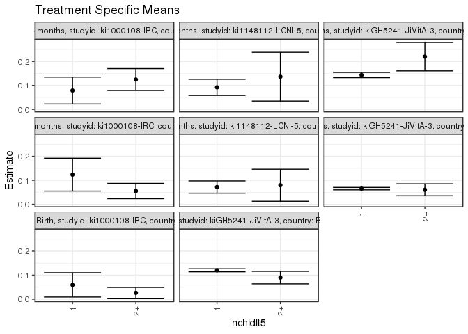

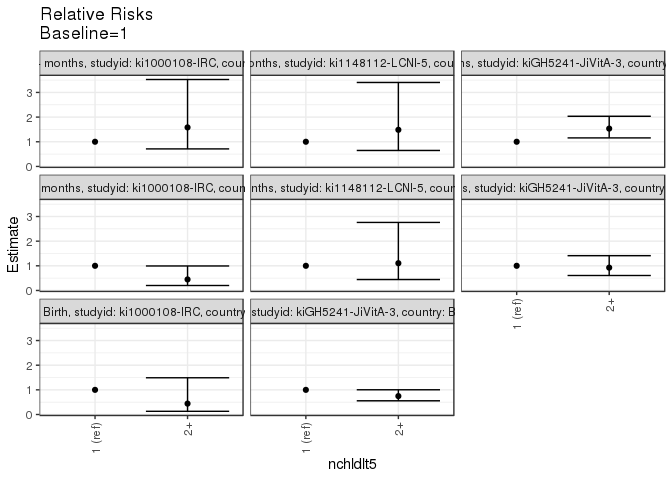

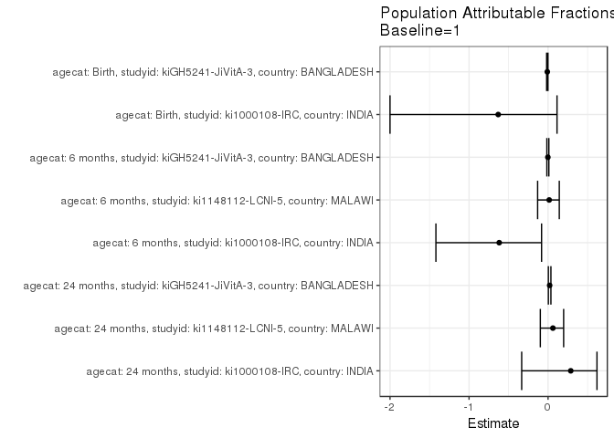

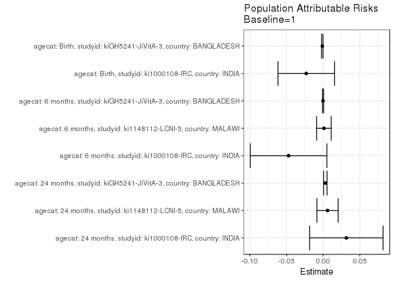

## Results Table

### Parameter: TSM

| agecat | studyid | country | intervention_level | baseline_level | estimate | ci_lower | ci_upper |
| --- | --- | --- | --- | --- | --- | --- | --- |
| Birth | ki1000108-IRC | INDIA | 1 | NA | 0.0595238 | 0.0088339 | 0.1102137 |
| Birth | ki1000108-IRC | INDIA | 2+ | NA | 0.0263158 | 0.0035133 | 0.0491183 |
| Birth | kiGH5241-JiVitA-3 | BANGLADESH | 1 | NA | 0.1204560 | 0.1141281 | 0.1267840 |
| Birth | kiGH5241-JiVitA-3 | BANGLADESH | 2+ | NA | 0.0899358 | 0.0639351 | 0.1159365 |
| 6 months | ki1000108-IRC | INDIA | 1 | NA | 0.1235955 | 0.0551000 | 0.1920910 |
| 6 months | ki1000108-IRC | INDIA | 2+ | NA | 0.0552764 | 0.0234711 | 0.0870816 |
| 6 months | ki1148112-LCNI-5 | MALAWI | 1 | NA | 0.0717949 | 0.0461462 | 0.0974435 |
| 6 months | ki1148112-LCNI-5 | MALAWI | 2+ | NA | 0.0793651 | 0.0125436 | 0.1461866 |
| 6 months | kiGH5241-JiVitA-3 | BANGLADESH | 1 | NA | 0.0651884 | 0.0601057 | 0.0702711 |
| 6 months | kiGH5241-JiVitA-3 | BANGLADESH | 2+ | NA | 0.0603567 | 0.0354599 | 0.0852534 |
| 24 months | ki1000108-IRC | INDIA | 1 | NA | 0.0786517 | 0.0226283 | 0.1346750 |
| 24 months | ki1000108-IRC | INDIA | 2+ | NA | 0.1243781 | 0.0786766 | 0.1700796 |
| 24 months | ki1148112-LCNI-5 | MALAWI | 1 | NA | 0.0918728 | 0.0581684 | 0.1255772 |
| 24 months | ki1148112-LCNI-5 | MALAWI | 2+ | NA | 0.1363636 | 0.0348086 | 0.2379187 |
| 24 months | kiGH5241-JiVitA-3 | BANGLADESH | 1 | NA | 0.1432509 | 0.1323689 | 0.1541330 |
| 24 months | kiGH5241-JiVitA-3 | BANGLADESH | 2+ | NA | 0.2196796 | 0.1605078 | 0.2788515 |

### Parameter: E(Y)

| agecat | studyid | country | intervention_level | baseline_level | estimate | ci_lower | ci_upper |
| --- | --- | --- | --- | --- | --- | --- | --- |
| Birth | ki1000108-IRC | INDIA | NA | NA | 0.0364964 | 0.0142521 | 0.0587406 |
| Birth | kiGH5241-JiVitA-3 | BANGLADESH | NA | NA | 0.1193223 | 0.1131771 | 0.1254674 |
| 6 months | ki1000108-IRC | INDIA | NA | NA | 0.0763889 | 0.0456586 | 0.1071192 |
| 6 months | ki1148112-LCNI-5 | MALAWI | NA | NA | 0.0728477 | 0.0488890 | 0.0968063 |
| 6 months | kiGH5241-JiVitA-3 | BANGLADESH | NA | NA | 0.0650316 | 0.0600684 | 0.0699948 |
| 24 months | ki1000108-IRC | INDIA | NA | NA | 0.1103448 | 0.0742216 | 0.1464680 |
| 24 months | ki1148112-LCNI-5 | MALAWI | NA | NA | 0.0978593 | 0.0656058 | 0.1301129 |
| 24 months | kiGH5241-JiVitA-3 | BANGLADESH | NA | NA | 0.1462014 | 0.1355059 | 0.1568969 |

### Parameter: RR

| agecat | studyid | country | intervention_level | baseline_level | estimate | ci_lower | ci_upper |
| --- | --- | --- | --- | --- | --- | --- | --- |
| Birth | ki1000108-IRC | INDIA | 1 | 1 | 1.0000000 | 1.0000000 | 1.0000000 |
| Birth | ki1000108-IRC | INDIA | 2+ | 1 | 0.4421053 | 0.1311881 | 1.4898994 |
| Birth | kiGH5241-JiVitA-3 | BANGLADESH | 1 | 1 | 1.0000000 | 1.0000000 | 1.0000000 |
| Birth | kiGH5241-JiVitA-3 | BANGLADESH | 2+ | 1 | 0.7466273 | 0.5558319 | 1.0029152 |
| 6 months | ki1000108-IRC | INDIA | 1 | 1 | 1.0000000 | 1.0000000 | 1.0000000 |
| 6 months | ki1000108-IRC | INDIA | 2+ | 1 | 0.4472362 | 0.2011829 | 0.9942205 |
| 6 months | ki1148112-LCNI-5 | MALAWI | 1 | 1 | 1.0000000 | 1.0000000 | 1.0000000 |
| 6 months | ki1148112-LCNI-5 | MALAWI | 2+ | 1 | 1.1054422 | 0.4429215 | 2.7589591 |
| 6 months | kiGH5241-JiVitA-3 | BANGLADESH | 1 | 1 | 1.0000000 | 1.0000000 | 1.0000000 |
| 6 months | kiGH5241-JiVitA-3 | BANGLADESH | 2+ | 1 | 0.9258804 | 0.6072955 | 1.4115939 |
| 24 months | ki1000108-IRC | INDIA | 1 | 1 | 1.0000000 | 1.0000000 | 1.0000000 |
| 24 months | ki1000108-IRC | INDIA | 2+ | 1 | 1.5813788 | 0.7095045 | 3.5246555 |
| 24 months | ki1148112-LCNI-5 | MALAWI | 1 | 1 | 1.0000000 | 1.0000000 | 1.0000000 |
| 24 months | ki1148112-LCNI-5 | MALAWI | 2+ | 1 | 1.4842657 | 0.6470885 | 3.4045492 |
| 24 months | kiGH5241-JiVitA-3 | BANGLADESH | 1 | 1 | 1.0000000 | 1.0000000 | 1.0000000 |
| 24 months | kiGH5241-JiVitA-3 | BANGLADESH | 2+ | 1 | 1.5335301 | 1.1567107 | 2.0331053 |

### Parameter: PAR

| agecat | studyid | country | intervention_level | baseline_level | estimate | ci_lower | ci_upper |
| --- | --- | --- | --- | --- | --- | --- | --- |
| Birth | ki1000108-IRC | INDIA | 1 | NA | -0.0230275 | -0.0616129 | 0.0155580 |
| Birth | kiGH5241-JiVitA-3 | BANGLADESH | 1 | NA | -0.0011338 | -0.0021455 | -0.0001221 |
| 6 months | ki1000108-IRC | INDIA | 1 | NA | -0.0472066 | -0.0995162 | 0.0051030 |
| 6 months | ki1148112-LCNI-5 | MALAWI | 1 | NA | 0.0010528 | -0.0089042 | 0.0110099 |
| 6 months | kiGH5241-JiVitA-3 | BANGLADESH | 1 | NA | -0.0001568 | -0.0009859 | 0.0006724 |
| 24 months | ki1000108-IRC | INDIA | 1 | NA | 0.0316931 | -0.0184770 | 0.0818632 |
| 24 months | ki1148112-LCNI-5 | MALAWI | 1 | NA | 0.0059865 | -0.0085053 | 0.0204784 |
| 24 months | kiGH5241-JiVitA-3 | BANGLADESH | 1 | NA | 0.0029505 | 0.0005928 | 0.0053081 |

### Parameter: PAF

| agecat | studyid | country | intervention_level | baseline_level | estimate | ci_lower | ci_upper |
| --- | --- | --- | --- | --- | --- | --- | --- |
| Birth | ki1000108-IRC | INDIA | 1 | NA | -0.6309524 | -2.0001346 | 0.1133712 |
| Birth | kiGH5241-JiVitA-3 | BANGLADESH | 1 | NA | -0.0095020 | -0.0179807 | -0.0010939 |
| 6 months | ki1000108-IRC | INDIA | 1 | NA | -0.6179775 | -1.4192668 | -0.0820846 |
| 6 months | ki1148112-LCNI-5 | MALAWI | 1 | NA | 0.0144522 | -0.1320826 | 0.1420198 |
| 6 months | kiGH5241-JiVitA-3 | BANGLADESH | 1 | NA | -0.0024109 | -0.0152320 | 0.0102483 |
| 24 months | ki1000108-IRC | INDIA | 1 | NA | 0.2872191 | -0.3337133 | 0.6190661 |
| 24 months | ki1148112-LCNI-5 | MALAWI | 1 | NA | 0.0611749 | -0.0979484 | 0.1972369 |
| 24 months | kiGH5241-JiVitA-3 | BANGLADESH | 1 | NA | 0.0201809 | 0.0038983 | 0.0361973 |